# Lasso experiments

Joshua Loftus

2/12/2021

## Warm-up: truncated normal

- Generate some `rnorm` data
- Truncate it above/below/both
- Plot histogram of truncated data
- Add conditional density to the plot

## Lasso simulations

### Functions to simulate data

The functions below do the following.

1. Simulate a sparse high-dimensional linear model
   $$\mathbf y = \mathbf X \beta + \varepsilon, \text{ for } \varepsilon \sim N(0, \sigma^2 I)$$
2. Fit ridge regression on a grid of $\lambda$ values
3. Iterate over multiple realizations of $\varepsilon$
4. Plot the MSE of estimated coefficients as a function of $\lambda$, with one line for each iterate

$$\text{MSE}(\hat \beta_\text{ridge}(\lambda))$$

```r
instance <- function(X, L, n, p, beta, mu) {
  # Add noise to signal
  Y <- mu + rnorm(n)
  y <- Y - mean(Y)
  # Fit model with glmnet
  ridge_fit <- glmnet(X, y, standardize = TRUE, intercept = FALSE, alpha = 0, lambda = L)
  # Extract estimate coefficients
  beta_mat <- coef(ridge_fit)[-1, ]
  # Compute MSE using true beta
  MSEs <- apply(beta_mat, 2, function(beta_hat) sum((beta_hat - beta)^2))
  out <- as.numeric(MSEs)
  names(out) <- L
  out
}
```

```r
high_dim_MSE_MC <- function(n, p, instances = 10) {
  ## Generating signal
  # A random sparse coefficient vector
  beta <- rnorm(p) * rpois(p, 1) * rbinom(p, 1, .5)
  # Fixed design matrix and mean
  X <- matrix(rnorm(n*p), nrow = n)
  mu <- X %*% beta
  # Lambda grid
  L <- exp(seq(
    from = log(max(n, p, sum(beta^2))),
    to = log(1e-3), length.out = n))
  ## Generate many noise instances
  # tidyverse version of replicate()
  output <- tibble(inst = 1:instances) %>%
    mutate(MSEs = map(inst, ~instance(X, L, n, p, beta, mu)))
  ## Transform output to long data.frame
  out_df <- output %>%
    unnest_longer("MSEs") %>%
    mutate(MSEs_id = as.numeric(MSEs_id))
  names(out_df) <- c("instance", "MSE", "lambda")
  ## Plot results
  out_df %>%
  ggplot(aes(lambda, MSE)) +
    ggtitle(bquote(
      list(sparsity == .(sum(beta != 0)),
           abs(abs(beta))^2 == .(round(sum(beta^2), 2)))
    )) +
    geom_line(aes(group = factor(instance)),
            alpha = .2,
            show.legend = FALSE) +
    scale_x_log10()
}
```

Delete the `set.seed()` line and run the function a few times to see the results.

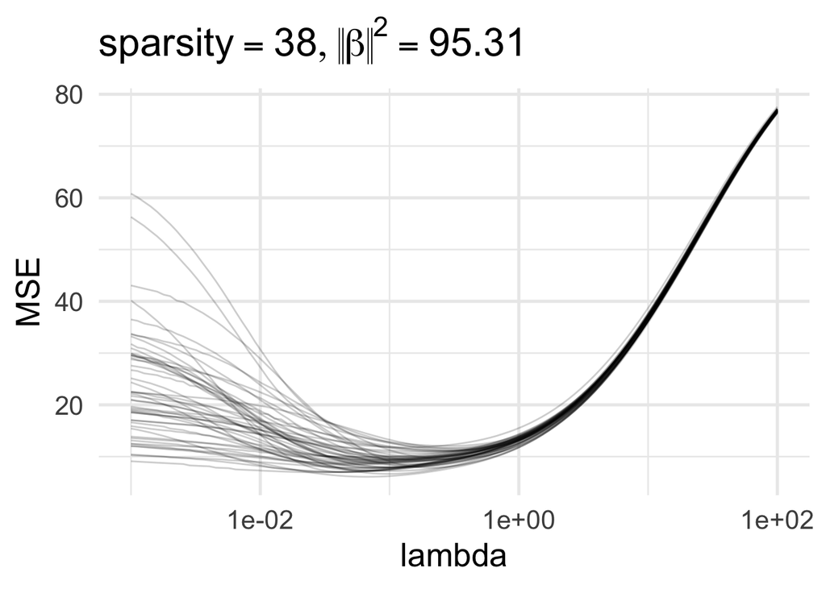

```r
set.seed(123456789) # delete this line
high_dim_MSE_MC(n = 100, p = 100, instances = 50)
```

### Performance of the lasso

Copy/paste and modify the previous functions and use them to experiment with the lasso

- Choose some metric to plot, like MSE of $\hat \beta_\text{lasso}(\lambda)$, out of sample prediction accuracy, or true/false positive rates of selected variables.
- Experiment with the parameters, $n$, $p$, sparsity, or making the design matrix $X$ have correlated columns, to see how the performance changes

### Inference for the lasso

```r
n <- 100
p <- 200
X <- matrix(rnorm(n*p), nrow = n)
Y <- rnorm(n)
# Compute lasso path
# while storing information required for
# conditional (truncated) inference
lasso_path <- lar(X, Y)
# Use AIC/BIC to choose model size
# and compute adjusted p-values
# in higher dimensions change mult
# to log(n) for BIC, log(p) for RIC
lasso_inference <- larInf(lasso_path, mult = 2, type = "aic", ntimes = 1)
lasso_inference
```

```
##
## Call:
## larInf(obj = lasso_path, type = "aic", mult = 2, ntimes = 1)
##
## Standard deviation of noise (specified or estimated) sigma = 0.961
##
## Testing results at step = 8, with alpha = 0.100
##
##  Var   Coef Z-score P-value LowConfPt UpConfPt LowTailArea UpTailArea
##   99 -0.255  -2.724   0.579    -8.604      Inf        0.05       0.00
##  168 -0.189  -2.043   0.906    -0.907      Inf        0.05       0.00
##   41  0.187   1.787   0.852      -Inf    5.804        0.00       0.05
##   75 -0.096  -1.029   0.449    -8.291    6.716        0.05       0.05
##   35  0.225   2.096   0.343      -Inf      Inf        0.00       0.00
##   30 -0.131  -1.225   0.811    -6.385      Inf        0.05       0.00
##  171 -0.236  -2.333   0.534      -Inf      Inf        0.00       0.00
##  186  0.234   1.704   0.391      -Inf      Inf        0.00       0.00
##
## Estimated stopping point from AIC rule = 8
```

OLS inference:

```r
relaxed_fit <- lm(Y ~ X[, lasso_inference$vars] - 1)
tidy(relaxed_fit)
```

```
## # A tibble: 8 x 5
##   term                       estimate std.error statistic p.value
##   <chr>                         <dbl>     <dbl>     <dbl>   <dbl>
## 1 X[, lasso_inference$vars]1  -0.233     0.0787    -2.97  0.00382
## 2 X[, lasso_inference$vars]2  -0.199     0.0787    -2.53  0.0133
## 3 X[, lasso_inference$vars]3   0.200     0.0886     2.26  0.0260
## 4 X[, lasso_inference$vars]4  -0.0771    0.0789    -0.978 0.331
## 5 X[, lasso_inference$vars]5   0.222     0.0913     2.44  0.0167
## 6 X[, lasso_inference$vars]6  -0.126     0.0913    -1.38  0.172
## 7 X[, lasso_inference$vars]7  -0.246     0.0857    -2.87  0.00505
## 8 X[, lasso_inference$vars]8   0.247     0.117      2.12  0.0370
```